# Homework 2 Report

## Name

Sahithi Uppalapati

### Setup

Read in the data with `read_csv()` and store the data as an R object named `dataset`. Check the data to make sure all of the expected observations and variables are there.

```r
## Load the data and any necessary packages here.

library(tidyverse)
maacs <- read_csv("maacs.csv.gz")
glimpse(maacs)
```

```
## Rows: 150
## Columns: 10
## $ id             <chr> "fd171e2d", "a66fc33a", "fc038e68", "8e28b8c2", "b2699b…
## $ age            <dbl> 14.72, 13.56, 14.50, 13.96, 16.63, 16.56, 17.18, 15.46,…
## $ gender         <chr> "male", "female", "male", "female", "female", "female",…
## $ fev1           <dbl> 1.78, 2.12, 2.73, 2.36, 3.13, 2.59, 2.60, 3.49, 2.29, 2…
## $ eNO            <dbl> 141.0, 68.0, 210.0, 23.0, 18.0, 128.0, 19.0, 26.0, 17.0…
## $ cough_days     <dbl> 2, 8, 2, 0, 14, 0, 0, 4, 1, 14, 2, 0, 0, 2, 14, 1, 2, 2…
## $ pm25           <dbl> 15.560, 18.890, 17.808, 13.956, 17.864, 43.784, 26.313,…
## $ no2            <dbl> NA, 12.827, NA, NA, 30.976, 10.590, NA, 32.902, 25.659,…
## $ mouse          <dbl> 2423, 939, 200, NA, 10371, 4789, 760, 264, 419, 187, 10…
## $ mouse_allergic <chr> "yes", "yes", "no", "no", "no", "yes", "yes", "no", "no…
```

```r
summary(maacs)
```

```
##       id                 age            gender               fev1
##  Length:150         Min.   : 5.000   Length:150         Min.   :0.650
##  Class :character   1st Qu.: 7.713   Class :character   1st Qu.:1.370
##  Mode  :character   Median :10.915   Mode  :character   Median :1.870
##                     Mean   :11.215                      Mean   :1.994
##                     3rd Qu.:14.758                      3rd Qu.:2.490
##                     Max.   :17.890                      Max.   :5.000
##                                                         NA's   :17
##       eNO           cough_days          pm25              no2
##  Min.   :  5.00   Min.   : 0.000   Min.   :  0.235   Min.   :  1.459
##  1st Qu.: 17.00   1st Qu.: 1.000   1st Qu.: 13.117   1st Qu.: 14.088
##  Median : 35.00   Median : 2.000   Median : 20.658   Median : 20.694
##  Mean   : 45.71   Mean   : 3.567   Mean   : 27.760   Mean   : 26.669
##  3rd Qu.: 63.00   3rd Qu.: 4.000   3rd Qu.: 35.118   3rd Qu.: 28.507
##  Max.   :210.00   Max.   :14.000   Max.   :198.463   Max.   :235.548
##  NA's   :17                        NA's   :20        NA's   :47
##      mouse         mouse_allergic
##  Min.   :   17.0   Length:150
##  1st Qu.:  316.5   Class :character
##  Median : 1207.5   Mode  :character
##  Mean   : 4444.9
##  3rd Qu.: 3819.5
##  Max.   :56846.0
##  NA's   :34
```

## Part 1

We will first consider the relationship between FEV1 and age. In general, it is expected that as children get older (and hence, larger in size), their FEV1 values should get higher.

Consider the statement “FEV1 values in children are higher in older children relative to younger children”.

Write a function in R that takes the `dataset` object as an argument and returns `TRUE` if the statement above is true for the dataset and `FALSE` otherwise.

NOTE: In order to write this function, you will need to translate the statement above into something that can be checked with the data. There are many ways in which you can do that translation correctly and you only need to pick one way here.

NOTE: For this part, do not use any plots.

```r
## Write your function here

fev1_age <- function(dataset) {
  data <- dataset %>%
    filter(!is.na(age), !is.na(fev1))

  corr <- cor(data$age, data$fev1, method = "pearson")

  return(corr > 0)
}


fev1_age(maacs)
```

```
## [1] TRUE
```

This outputs True, which shows that FEV1 values in children are higher in older children relative to younger children

## Part 2

Fit a linear regression model with FEV1 as the outcome and age as a predictor.

How much does FEV1 change for a 1-year increase in the child’s age?

```r
## Add your code here
model <- lm(fev1 ~ age, data = maacs)
summary(model)
```

```
##
## Call:
## lm(formula = fev1 ~ age, data = maacs)
##
## Residuals:
##      Min       1Q   Median       3Q      Max
## -1.51099 -0.27100  0.00196  0.23616  2.15477
##
## Coefficients:
##              Estimate Std. Error t value Pr(>|t|)
## (Intercept) -0.001199   0.134696  -0.009    0.993
## age          0.171162   0.010984  15.583   <2e-16 ***
## ---
## Signif. codes:  0 '***' 0.001 '**' 0.01 '*' 0.05 '.' 0.1 ' ' 1
##
## Residual standard error: 0.4827 on 131 degrees of freedom
##   (17 observations deleted due to missingness)
## Multiple R-squared:  0.6496, Adjusted R-squared:  0.6469
## F-statistic: 242.8 on 1 and 131 DF,  p-value: < 2.2e-16
```

Write your data analysis statement interpreting the regression model here:

The model above shows that for each 1 year increase in age, FEV! increases approximately by 0.17 liters. This goes to show that older children tend to have better lung function compared to that of younger children.

## Part 3

Develop **three** supporting premises derived from the data that support the statement you wrote in Part 2. These can be plots, other summary statistics, or model results.

NOTE:

- At least one supporting premise should use a plot.
- Do not use the code you write in Part 1 as a supporting premise

```r
## Add your code here

#correlation
maacs %>%
  summarise(corr = cor(age, fev1, use = "complete.obs"))
```

```
## # A tibble: 1 × 1
##    corr
##   <dbl>
## 1 0.806
```

```r
#regression
coef(model)["age"]
```

```
##       age
## 0.1711623
```

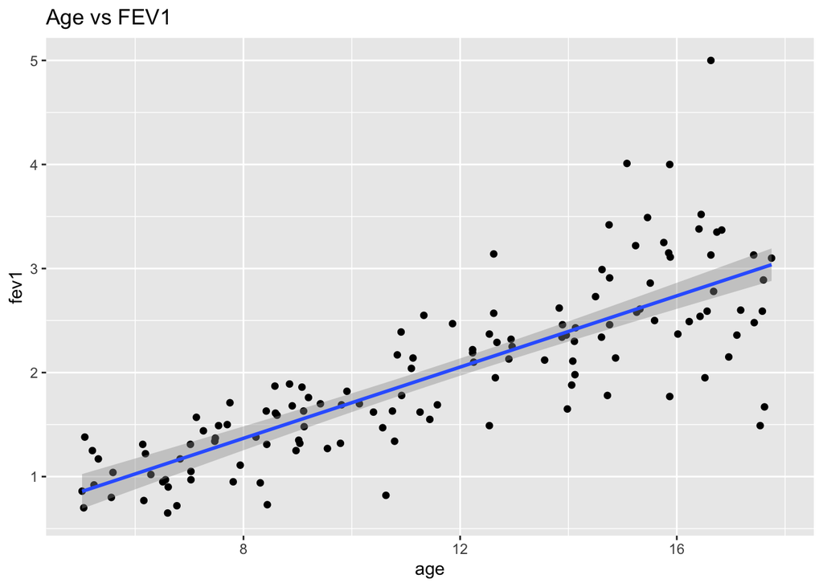

```r
#plot
ggplot(maacs, aes(x = age, y = fev1)) +
  geom_point() +
  geom_smooth(method = "lm", se = TRUE) +
  labs(title = "Age vs FEV1")
```

Write the three supporting premise statements here:

1. The correlation between the two variables age and FEV1 is positive, which goes to show that older children have higher lung function
2. The regression for the slope is positive, which shows that an additional year of age is associated with an increase in FEV1
3. The scatter plot shows an upward trend, which confirms that FEV1 does in fact increase with age.

## Part 4

For each of the supporting premises above, write a function that takes the `dataset` object as an argument and returns `TRUE` if the supporting premise statement above is true for the dataset and `FALSE` otherwise.

For statements involving plots, instead of returning `TRUE` or `FALSE`, you function should do two things:

1. Produce the plot that is used in the statement
2. Produce a hypothetical version of the plot in the event that the statement is true. This can be done using simulated data or by simply hand drawing a plot.

```r
## Function for supporting premise statement 1
corr_func <- function(dataset) {
  corr <- cor(dataset$age, dataset$fev1, use = "complete.obs")
  return(corr > 0)
}
```

```r
## Function for supporting premise statement 2
slope_func <- function(dataset) {
  model <- lm(fev1 ~ age, data = dataset)
  slope <- coef(model)["age"]
  return(slope > 0)
}
```

```r
## Function for supporting premise statement 3
plot_func <- function(dataset) {
  plot1 <- ggplot(dataset, aes(x = age, y = fev1)) +
    geom_point() +
    geom_smooth(method = "lm", se = TRUE) +
    labs(title = "Age vs FEV1")
  print(plot1)

  # plot (if statement is true)
  new_data <- data.frame(
    age = seq(5, 17, by = 1),
    fev1 = seq(1.5, 3.5, length.out = 13) + rnorm(13, 0, 0.1)
  )

  plot2 <- ggplot(new_data, aes(x = age, y = fev1)) +
    geom_point(color = "red") +
    geom_smooth(method = "lm", se = FALSE, color = "red") +
    labs(title = "Hypothetical Plot (If True)")
  print(plot2)
}
```

Execute each of your function and show that the produce the expected output.

```r
corr_func(maacs)
```

```
## [1] TRUE
```

```r
slope_func(maacs)
```

```
##  age
## TRUE
```

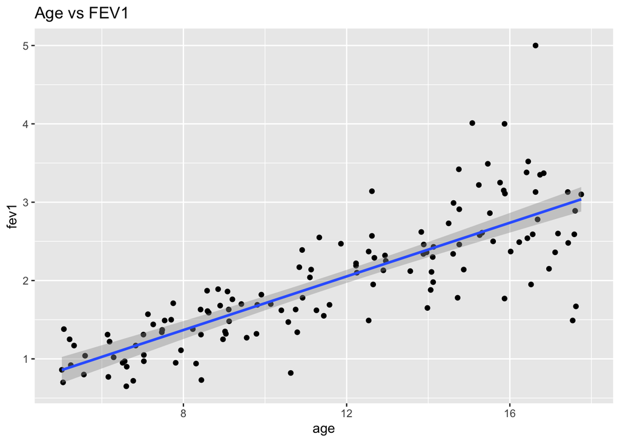

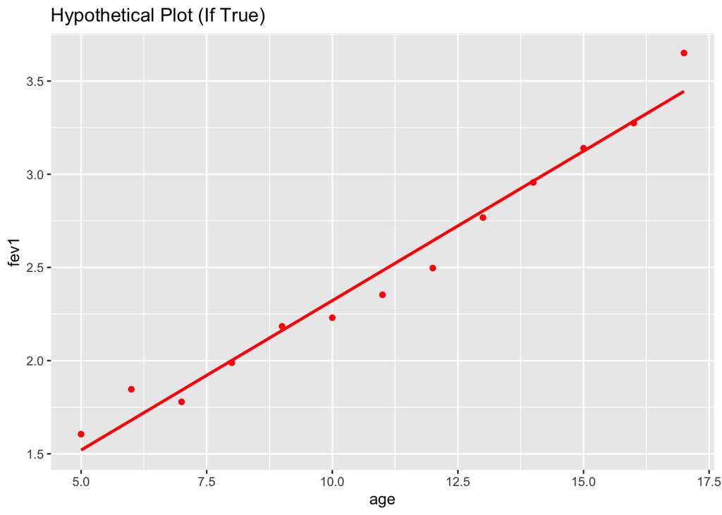

```r
plot_func(maacs)
```

In the output above, we can see that we output True showing that the supportive statement is true for the data set. The graphs also support this, with the first plot produces the positive regression and the second plot shows the hypothetical scenario if the statement were to be true.

# Part 5

Describe one alternative to the primary statement “FEV1 values in children are higher in older children relative to younger children”.

Create a fault tree for the alternative outcome describing how the alternative outcome could be realized in the data even if the primary statement were true.

Your fault tree should be created as a separate image and does not need to be created in R. Upload the image of the fault tree to Canvas.

My Alternative statement:

FEV1 values in children do not increase with age as other factors like exposure to pollutants or asthma severity may drive differences in lung function